# Read external data

# 1 Introduction

Let say that you receive a raw `data.frame` with coordinate points per row, and I want to create a Thematic map with it, how can I make it using `{ggplot2}`? Or that you use a package to get spatial data but in a object class like `SpatVector` or `SpatialPolygonsDataFrame`, how can I use them with `{ggplot2}`?

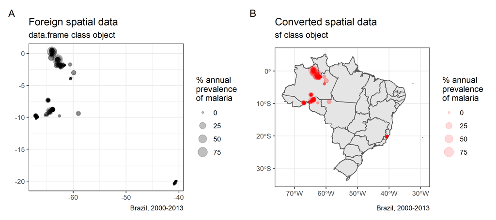

Figure 1. (A) Map from a raw data.frame with coordinate points. (B) Dot map with the same data converted to a `sf` object.

We need `sf` class objects to create `ggplot` maps! So, today we are going to learn how to **convert foreign** spatial objects to `sf`, either polygon or point data, to keep making `ggplot2` maps!

# 2 Learning objectives

1. Convert **foreign** objects to **`sf` class** using the `st_as_sf()` function from the `{sf}` package.
2. Convert foreign **polygon** data in `SpatVector` class to `sf`.
3. Convert foreign **point** data in `data.frame` class to `sf`.

# 3 Prerequisites

This lesson requires the following packages:

```r
if(!require('pacman')) install.packages('pacman')

pacman::p_load(malariaAtlas,
               ggplot2,
               cholera,
               geodata,
               dplyr,
               here,
               sf)

pacman::p_load_gh("afrimapr/afrilearndata",
                  "wmgeolab/rgeoboundaries")
```

# 4 Mapping country borders with `{geodata}`

An advantage of the `{geodata}` package is that it downloads country borders data with a *multiple column output*, providing the names of all the levels above the one requested.

For example, here is an example with the first three administrative levels in Bolivia:

```r
bolivia_level3 <- gadm(country = "Bolivia", level = 3, path = tempdir())
```

```r
bolivia_level3 %>%

  as_tibble() %>%
  select(starts_with("NAME_")) #👈👈👈👈👈👈👈👈👈👈👈👈👈
```

```
## # A tibble: 344 × 3
##    NAME_1 NAME_2                 NAME_3
##    <chr>  <chr>                  <chr>
##  1 Beni   Cercado                San Javier
##  2 Beni   Cercado                Trinidad
##  3 Beni   General José Ballivián Puerto Menor de Rurrenabaque
##  4 Beni   General José Ballivián Reyes
##  5 Beni   General José Ballivián San Borja
##  6 Beni   General José Ballivián Santa Rosa
##  7 Beni   Iténez                 Baures
##  8 Beni   Iténez                 Huacaraje
##  9 Beni   Iténez                 Magdalena
## 10 Beni   Mamoré                 Puerto Siles
## # ℹ 334 more rows
```

This is useful for situations where you want to `filter()` only a specific subset of sub-divisions (e.g. level 3) within a region (level 1) or department (level 2).

```r
bolivia_level3 %>%

  as_tibble() %>%
  select(starts_with("NAME_")) %>%

  filter(NAME_1 == "Santa Cruz") #👈👈👈👈👈👈👈👈👈👈👈👈👈👈
```

```
## # A tibble: 56 × 3
##    NAME_1     NAME_2         NAME_3
##    <chr>      <chr>          <chr>
##  1 Santa Cruz Andrés Ibáñez  Cotoca
##  2 Santa Cruz Andrés Ibáñez  El Torno
##  3 Santa Cruz Andrés Ibáñez  La Guardia
##  4 Santa Cruz Andrés Ibáñez  Porongo
##  5 Santa Cruz Andrés Ibáñez  Santa Cruz de la Sierra
##  6 Santa Cruz Angel Sandoval San Matías
##  7 Santa Cruz Chiquitos      Pailón
##  8 Santa Cruz Chiquitos      Roboré
##  9 Santa Cruz Chiquitos      San José
## 10 Santa Cruz Cordillera     Boyuibe
## # ℹ 46 more rows
```

However, I can not create `ggplot` maps with it because it is a `SpatVector` class object:

```r
gadm(country = "Bolivia", level = 3, path = tempdir())
```

```
👉 class       : SpatVector 👈
   geometry    : polygons
   dimensions  : 344, 16  (geometries, attributes)
   extent      : -69.64525, -57.45443, -22.90657, -9.670923
   coord. ref. : +proj=longlat +datum=WGS84 +no_defs
```

## Convert foreign Polygon geometries to `sf`

The best way to solve this issue is to use the `st_as_sf()` function from the `{sf}` package

```r
# spatvector
bolivia_level3 %>% class()
```

```
## [1] "SpatVector"
## attr(,"package")
## [1] "terra"
```

```r
# sf
bolivia_level3 %>% st_as_sf() %>% class() #👈👈👈👈👈👈👈👈
```

```
## [1] "sf"         "data.frame"
```

This solution is useful for object classes like `SpatVector` and `SpatialPolygonsDataFrame`.

Convert the country borders of Germany from `SpatVector` to a `sf` class object using the `st_as_sf()` function:

```r
gadm(country = "Germany", level = 2, path = tempdir()) %>%
  ...........
```

Now with `sf` objects, we can create a ggplot like this:

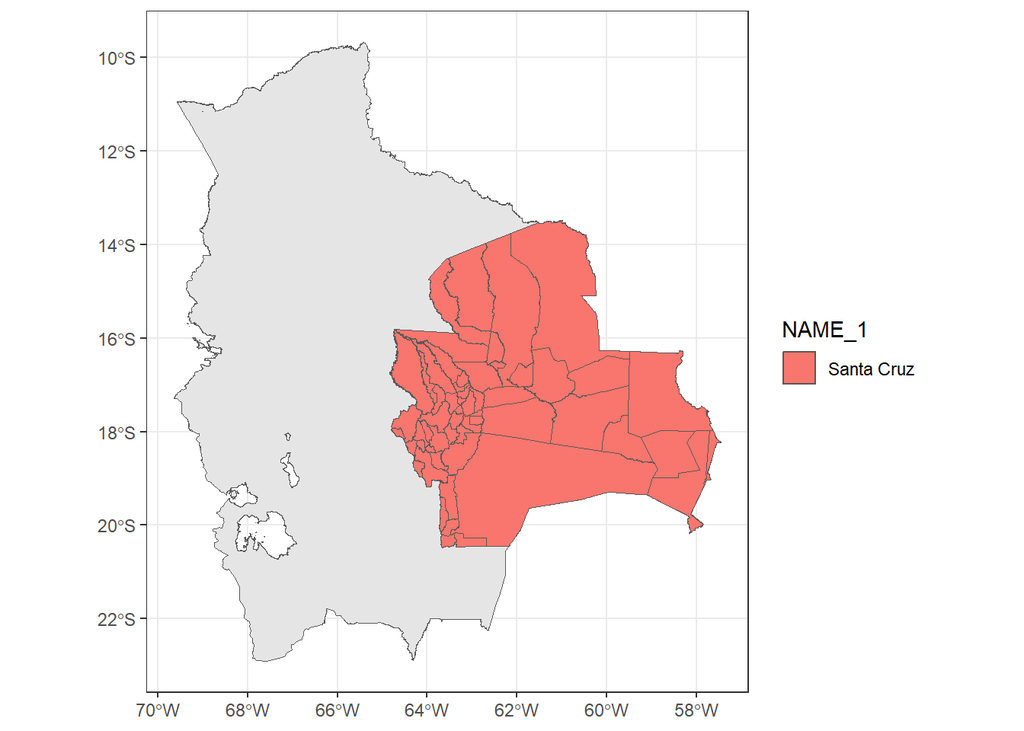

```r
ggplot() +
  geom_sf(data = geoboundaries(country = "Bolivia")) +
  geom_sf(data = bolivia_level3 %>%

            st_as_sf() %>%                 #👈👈👈👈

            filter(NAME_1 == "Santa Cruz"),
          mapping = aes(fill = NAME_1))
```

## Vector data

**Why is the class object called `SpatVector`?**

- “SpatVector” stands for *“Spatial Vector”*, and “Vector” stands for **“Vector data”**.
- **Vector data** is the formal name for the *Geometry types* like Point, Lines, and Polygons.
- It requires a **Coordinate Reference System (CRS)** to relate the spatial elements of the data with the *surface of Earth*.
- It is also the **most common format** of Spatial data used in GIS. Which is commonly stored in Shapefiles.

Do not get confused by the `vector` class object, which is an R class just like `data.frame` and `matrix`.

Above is an example of converting *foreign* **Polygon** data to `sf` class. Now let’s see briefly see how to convert *foreign* **Point** data.

# 5 Disease information with `{malariaAtlas}`

The `{malariaAtlas}` package download, visualize and manipulate global malaria data hosted by the [Malaria Atlas Project](https://malariaatlas.org/).

The `malariaAtlas` package enables users to download data like:

- parasite rate (PR) survey data (*Plasmodium falciparum* and *Plasmodium vivax*)
- mosquito occurrence data

## Parasite Rate surveys

The `getPR()` function downloads all the publicly available PR points for a country (or countries) and returns it as a `data.frame`.

```r
zimbabwe_malaria_pr <- getPR(country = "Zimbabwe", species = "BOTH")
```

The `species` argument is a string specifying the Plasmodium species and can be `Pf` (*Plasmodium falciparum*), `Pv` (*Plasmodium vivax*) or `BOTH`.

The output is a `data.frame` object that contains `longitude` and `latitude` as variables:

```r
class(zimbabwe_malaria_pr)
```

```
## [1] "pr.points"  "data.frame"
```

```r
zimbabwe_malaria_pr %>%
  as_tibble()
```

```
## # A tibble: 567 × 28
##    dhs_id site_id site_name    latitude longitude rural_urban country country_id
##    <lgl>    <int> <chr>           <dbl>     <dbl> <chr>       <chr>   <chr>
##  1 NA       16142 Chilonga        -18.4      27.2 UNKNOWN     Zimbab… ZWE
##  2 NA       17018 Ume - Kahobo    -17.8      28.8 UNKNOWN     Zimbab… ZWE
##  3 NA       18443 Bandanyenje     -18.9      32.0 UNKNOWN     Zimbab… ZWE
##  4 NA          68 Piringani       -17.0      30.1 UNKNOWN     Zimbab… ZWE
##  5 NA       19390 Zidulini        -18.7      28.7 UNKNOWN     Zimbab… ZWE
##  6 NA       17564 Lutumba         -22.1      30.2 UNKNOWN     Zimbab… ZWE
##  7 NA       14287 Seula School    -21.6      28.4 UNKNOWN     Zimbab… ZWE
##  8 NA        2943 Ndlovu          -18.9      27.8 UNKNOWN     Zimbab… ZWE
##  9 NA       11029 Bambaninga      -20.4      31.8 UNKNOWN     Zimbab… ZWE
## 10 NA       20058 Pumula Miss…    -19.6      27.1 UNKNOWN     Zimbab… ZWE
## # ℹ 557 more rows
## # ℹ 20 more variables: continent_id <chr>, month_start <int>, year_start <int>,
## #   month_end <int>, year_end <int>, lower_age <int>, upper_age <int>,
## #   examined <int>, positive <int>, pr <dbl>, species <chr>, method <chr>,
## #   rdt_type <chr>, pcr_type <lgl>, malaria_metrics_available <chr>,
## #   location_available <chr>, permissions_info <chr>, citation1 <chr>,
## #   citation2 <chr>, citation3 <chr>
```

Download the publicly available Parasite Ratio (PR) points for *Plasmodium falciparum* in `Sierra Leone` using the `{malariaAtlas}` package.

```r
q3 <- ________(________ = "Sierra Leone",species = "Pf")
q3
```

`autoplot()` can be used to quickly and easily visualize the downloaded PR survey points.

```r
autoplot(zimbabwe_malaria_pr)
```

[output not shown]

However, if you would like to make a **custom plot** for your particular research needs, with complete control of the *output aesthetics*, you would probably prefer `{ggplot2}` for the work!

## Convert foreign Point geometries to `sf`

To convert a `data.frame` to an `sf` object, we can use the `st_as_sf()` from the `{sf}` package.

In case of **Point** patterns data (like for a **Dot map**):

- the `coords` argument need to specify the names of the variables holding the **Coordinates**, and
- the `crs` argument specify the **Coordinate Reference System (CRS)** to be assigned (here WGS84, which is the CRS code #`4326`).

```r
zimbabwe_malaria_pr_sf <-
  # data frame
  zimbabwe_malaria_pr %>%
  # convert to sf
  sf::st_as_sf(coords = c("longitude","latitude"),  #👈👈👈👈👈👈
               crs = 4326)
```

Inside the **`coords` argument**,you need to pay attention to two things:

- You need to use `"quotation_marks"` for each column name,
- First write the `longitude`, and then the `latitude`.

**Mission accomplished!** This is the output of the conversion:

```r
zimbabwe_malaria_pr_sf %>%
  dplyr::select(site_name,pr)
```

```
## Simple feature collection with 567 features and 2 fields
## Geometry type: POINT
## Dimension:     XY
## Bounding box:  xmin: 25.8063 ymin: -22.2333 xmax: 32.9708 ymax: -16.0662
## Geodetic CRS:  WGS 84
## First 10 features:
##         site_name     pr                 geometry
## 9        Chilonga 0.0000    POINT (27.1667 -18.4)
## 11   Ume - Kahobo 0.0750 POINT (28.8209 -17.8091)
## 17    Bandanyenje 0.0000   POINT (31.95 -18.8667)
## 19      Piringani 0.0000 POINT (30.1333 -16.9667)
## 21       Zidulini 0.0080 POINT (28.6667 -18.7333)
## 24        Lutumba 0.0000  POINT (30.1757 -22.122)
## 26   Seula School 0.0000 POINT (28.4033 -21.6176)
## 30         Ndlovu 0.0800   POINT (27.75 -18.8667)
## 34     Bambaninga 0.0080 POINT (31.7562 -20.4146)
## 38 Pumula Mission 0.0078   POINT (27.116 -19.617)
```

Now we have converted our `data.frame` into an `sf` object and can directly plot this object with `{ggplot2}` code:

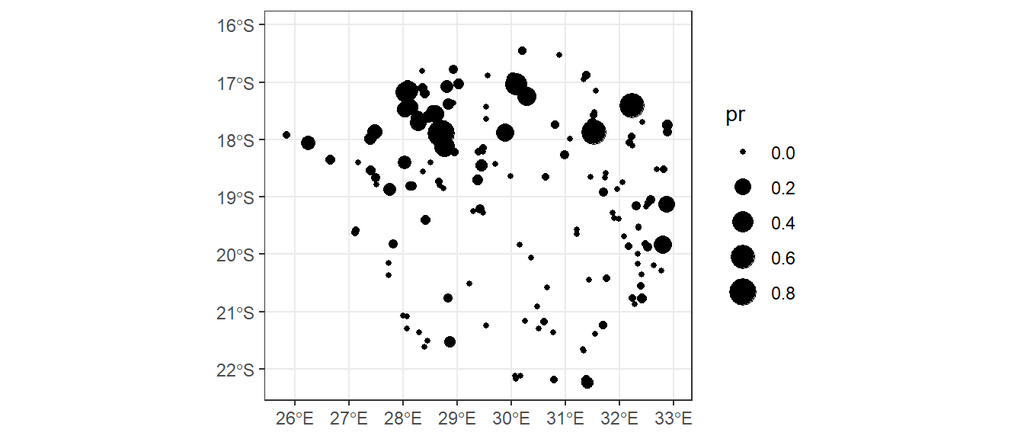

```r
ggplot(data = zimbabwe_malaria_pr_sf) +
  geom_sf(aes(size = pr))
```

Or add one previous layer with the administrative boundaries of Zimbabwe:

```r
zimbabwe_boundaries_adm1 <- geoboundaries(country = "Zimbabwe",
                                         adm_lvl = 1)
```

In the same ggplot:

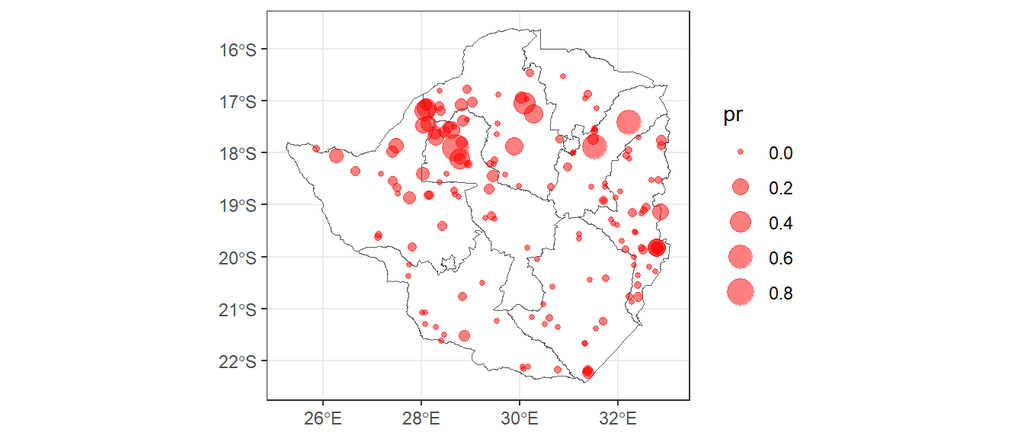

```r
ggplot() +
  # boundaries data
  geom_sf(data = zimbabwe_boundaries_adm1,
          fill = "white") +
  # disease data
  geom_sf(data = zimbabwe_malaria_pr_sf,
          aes(size = pr),
          color = "red",
          alpha=0.5)
```

`sf::st_as_sf()` does not allow missing values in coordinates!

So you can use `{dplyr}` verbs like `filter()` to drop problematic rows from variable `x` using this notation:`filter(!is.na(x))`.

With the publicly available Parasite Ratio (PR) points of *Plasmodium falciparum* in Sierra Leone stored in `q3`:

Convert its `data.frame` output to a `sf` object using the `st_as_sf()` function, with the code `4326` to set a `WGS84` CRS. (More on all these codes coming soon, don’t be intimidated !)

```r
q4 <-
  q3 %>%
  filter(!is.na(longitude)) %>%
  sf::________(coords = c("________","________"),
               crs = 4326)
q4
```

# 6 Wrap up

In this lesson, we have learned how to **convert foreign** *Polygon* and *Point* data to a `sf` class object from `SpatVector` and `data.frame` objects, respectively. We also learned about **Vector data** and how **Point data** needs a *Coordinate Reference Systems (CRS)* to obtain an `sf` object.

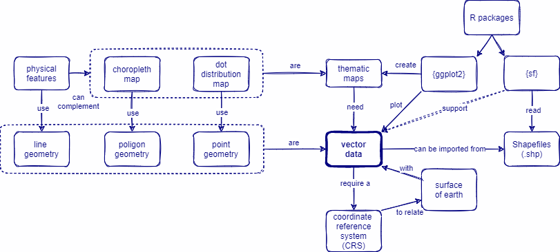

Figure 2. Concept map

# Contributors

The following team members contributed to this lesson:

- [ANDREE VALLE CAMPOS](https://thegraphcourses.org/members/avallecam/)  
  R Developer and Instructor, the GRAPH Network

  Motivated by reproducible science and education
- [LAURE VANCAUWENBERGHE](https://thegraphcourses.org/members/lolovanco)  
  Data analyst, the GRAPH Network

  A firm believer in science for good, striving to ally programming, health and education

# References

Some material in this lesson was adapted from the following sources:

- *Seimon, Dilinie. Administrative Boundaries.* (2021). Retrieved 15 April 2022, from https://rspatialdata.github.io/admin_boundaries.html
- *Varsha Ujjinni Vijay Kumar. Malaria.* (2021). Retrieved 15 April 2022, from https://rspatialdata.github.io/malaria.html
- *Batra, Neale, et al. The Epidemiologist R Handbook. Chapter 28: GIS Basics*. (2021). Retrieved 01 April 2022, from https://epirhandbook.com/en/gis-basics.html
- *Lovelace, R., Nowosad, J., & Muenchow, J. Geocomputation with R. Chapter 2: Geographic data in R*. (2019). Retrieved 01 April 2022, from https://geocompr.robinlovelace.net/spatial-class.html
- *Moraga, Paula. Geospatial Health Data: Modeling and Visualization with R-INLA and Shiny. Chapter 2: Spatial data and R packages for mapping*. (2019). Retrieved 01 April 2022, from https://www.paulamoraga.com/book-geospatial/sec-spatialdataandCRS.html

This work is licensed under the [Creative Commons Attribution Share Alike](https://creativecommons.org/licenses/by-sa/4.0/) license.